# UNIT10A：相關性，變數之間的關係

中山大學管理學院 卓雍然

2019-11-11 20:05:37

```r
pacman::p_load(dplyr, ggplot2, car, vcd, GGally, mvtnorm)
```

### 【A】批發商資料集

```r
W = read.csv('data/wholesales.csv')
W$Channel = factor( paste0("Ch",W$Channel) )
W$Region = factor( paste0("Reg",W$Region) )
W[3:8] = lapply(W[3:8], log, base=10)
summary(W)
```

```
 Channel    Region        Fresh            Milk         Grocery
 Ch1:298   Reg1: 77   Min.   :0.477   Min.   :1.74   Min.   :0.477
 Ch2:142   Reg2: 47   1st Qu.:3.495   1st Qu.:3.19   1st Qu.:3.333
           Reg3:316   Median :3.930   Median :3.56   Median :3.677
                      Mean   :3.792   Mean   :3.53   Mean   :3.666
                      3rd Qu.:4.229   3rd Qu.:3.86   3rd Qu.:4.028
                      Max.   :5.050   Max.   :4.87   Max.   :4.968
     Frozen     Detergents_Paper   Delicassen
 Min.   :1.40   Min.   :0.477    Min.   :0.477
 1st Qu.:2.87   1st Qu.:2.409    1st Qu.:2.611
 Median :3.18   Median :2.912    Median :2.985
 Mean   :3.17   Mean   :2.947    Mean   :2.895
 3rd Qu.:3.55   3rd Qu.:3.594    3rd Qu.:3.260
 Max.   :4.78   Max.   :4.611    Max.   :4.681
```

### 【B】連續變數的相關性(係數) Correlation

**B1a. 點狀圖 Simple Scatter Plot**

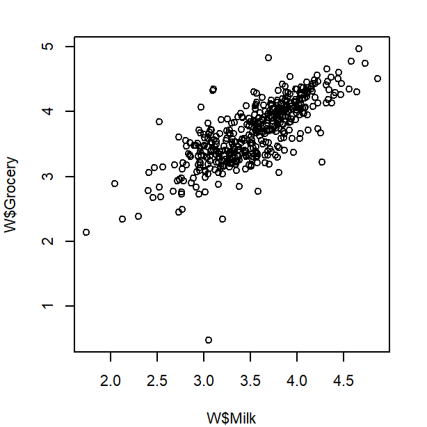

```r
par(cex=0.7, mar=c(4,4,2,2))
plot(W$Milk, W$Grocery)
```

**B1b. 點狀圖+回歸線 Scatter Plot with Regrssion Line**

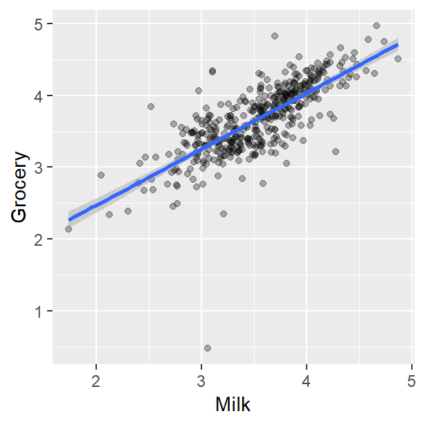

```r
ggplot(W, aes(x=Milk, y=Grocery)) +
  geom_point(alpha=0.3) +
  geom_smooth(method="lm")
```

**B2. 回歸係數 Correlation**
$$r_{xy}=\frac{Cov(x,y)}{\sigma_x \sigma_y}
=\frac{\Sigma_{i=1}^n(x_i - \bar{x})(y_i - \bar{y})}
{\sqrt{\Sigma_{i=1}^n(x_i - \bar{x})^2} \sqrt{\Sigma_{i=1}^n(y_i - \bar{y})^2}}$$

```r
cor(W$Milk, W$Grocery)
```

```
[1] 0.75885
```

**B3. 回歸係數檢定 Correlation Test**

```r
cor.test(W$Milk, W$Grocery)
```

```
    Pearson's product-moment correlation

data:  W$Milk and W$Grocery
t = 24.4, df = 438, p-value <0.0000000000000002
alternative hypothesis: true correlation is not equal to 0
95 percent confidence interval:
 0.71617 0.79588
sample estimates:
    cor
0.75885
```

💡 ： $p-value$: 給定虛無假設($H_0:r=0$)，檢定統計量($t$)大於觀察值($24.4$)的機率

🗿 ： 當$p = 0.05$時，對立假設($H_A$)為真的機率是？

💡 ： 貝氏定理：$P(A|B) = P(B|A) \cdot P(A) / P(B)$

**B4. Simulating Bi-Variate Normal Distibution**

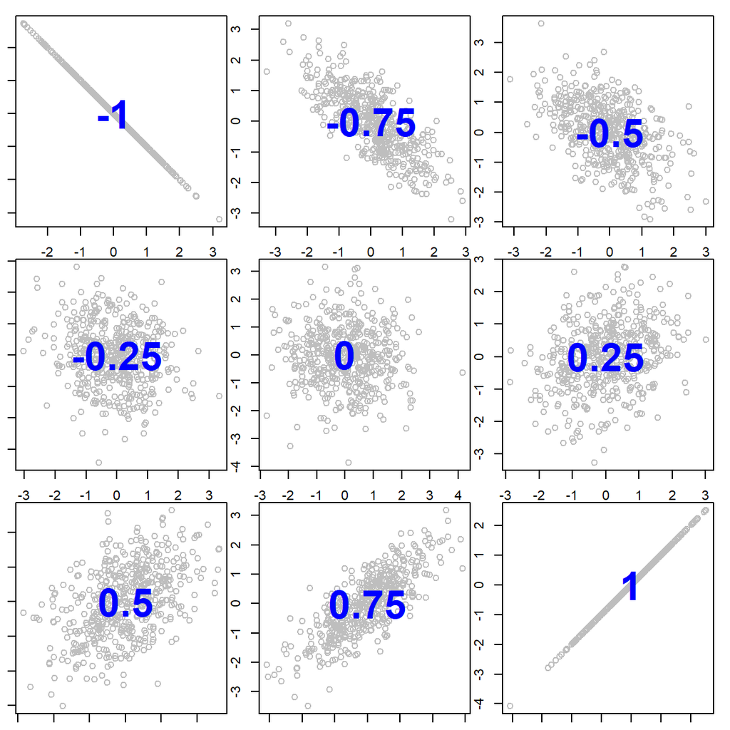

```r
par(cex=0.7, mar=c(1,1,1,1), mfrow=c(3,3))
for(r in seq(-1,1,0.25)) {
  mu = c(0,0)
  sigma = matrix(c(1,r,r,1),nrow=2)   # covariance matrix
  rmvnorm(500, mu, sigma) %>% plot(col='gray')
  text(0,0,r,cex=3,col='blue',font=2)
  }
```

### 【C】相關性矩陣

**C1. Matrix of Correlation Coefficients**

```r
cor(W[,3:8]) %>% round(3)
```

```
                  Fresh   Milk Grocery Frozen Detergents_Paper Delicassen
Fresh             1.000 -0.020  -0.133  0.384           -0.156      0.255
Milk             -0.020  1.000   0.759 -0.055            0.678      0.338
Grocery          -0.133  0.759   1.000 -0.165            0.796      0.236
Frozen            0.384 -0.055  -0.165  1.000           -0.212      0.255
Detergents_Paper -0.156  0.678   0.796 -0.212            1.000      0.167
Delicassen        0.255  0.338   0.236  0.255            0.167      1.000
```

💡 ： 相關性矩陣：(a)對角線等於1；(b)左下、右上對稱

**C1. Matrix of Scatter Plots**

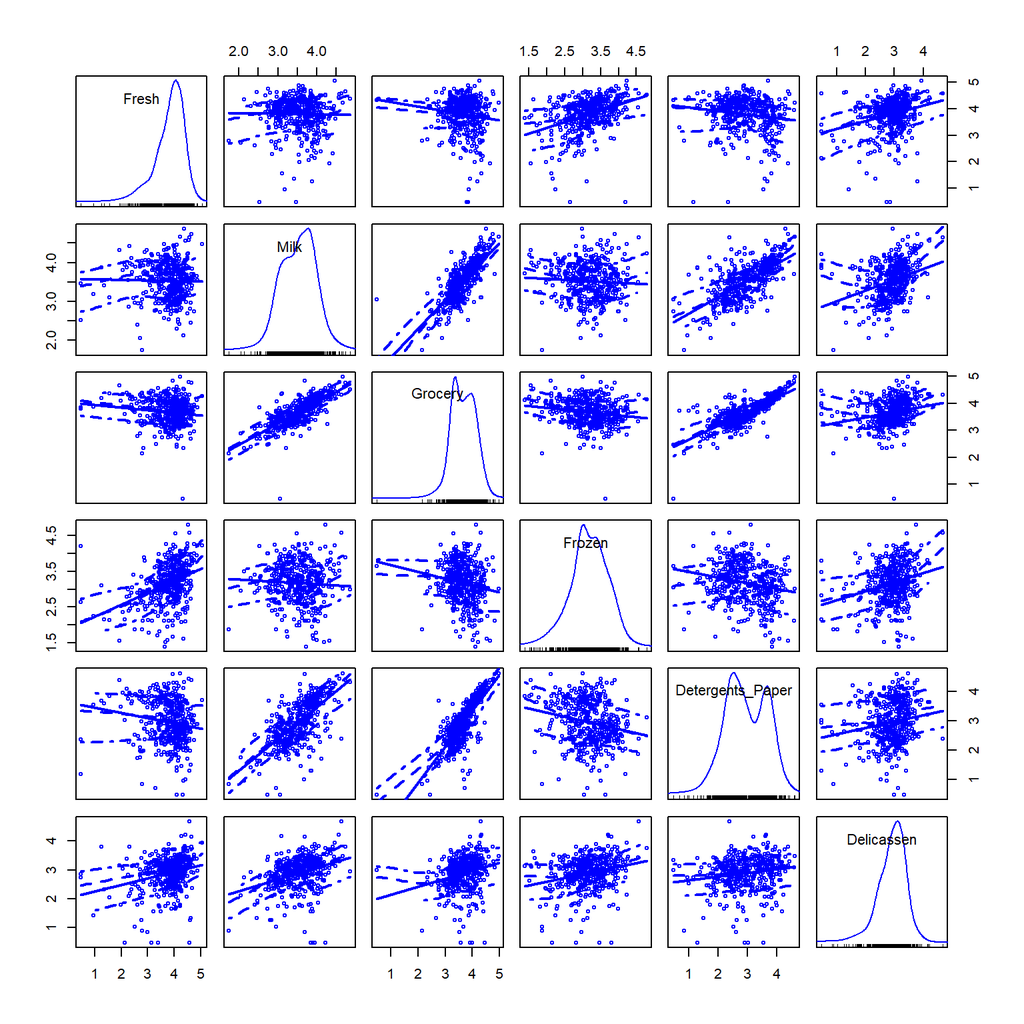

```r
car::scatterplotMatrix(W[,3:8])
```

### 【D】類別變數之間的關聯性 Association

**D1. 關聯性卡方檢定 Chisq-Test for Association**

```r
table(W$Channel, W$Region) %>% chisq.test()
```

```
    Pearson's Chi-squared test

data:  .
X-squared = 4.35, df = 2, p-value = 0.11
```

- The association between `Channel` and `Region` is not significant
- I.e., The distribution of `Channel` does not depends on `Region` and vice versa.

**D2. 馬賽克圖 Mosaic Plot**

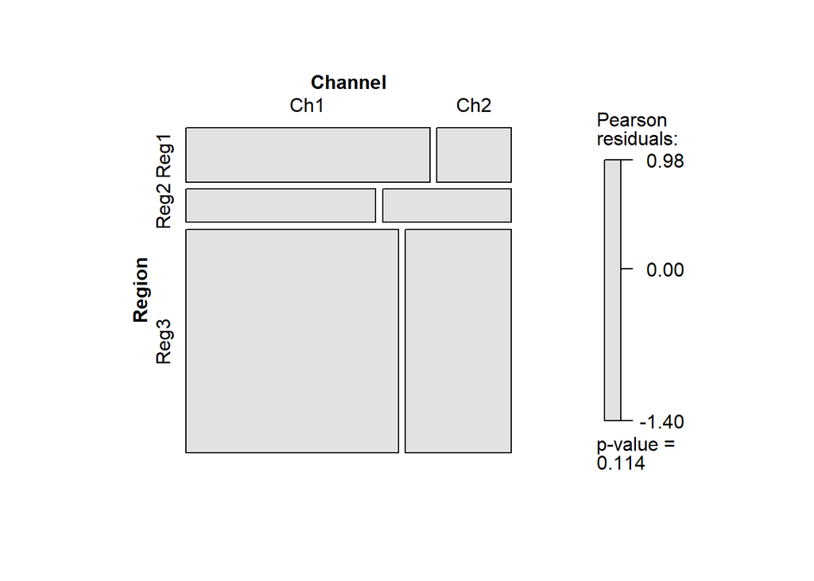

```r
library(vcd)
structable(Channel ~ Region, W) %>%
  mosaic(shade=T, labeling=labeling_residuals)
```

**D3. Another Example**

```r
haireye <- margin.table(HairEyeColor, 1:2)
haireye
```

```
       Eye
Hair    Brown Blue Hazel Green
  Black    68   20    15     5
  Brown   119   84    54    29
  Red      26   17    14    14
  Blond     7   94    10    16
```

頭髮顏色的邊際機率

```r
(mpHair = rowSums(haireye)/sum(haireye)) # marginal prob.
```

```
  Black   Brown     Red   Blond
0.18243 0.48311 0.11993 0.21453
```

眼睛顏色的邊際機率

```r
(mpEye = colSums(haireye)/sum(haireye)) # marginal prob.
```

```
  Brown    Blue   Hazel   Green
0.37162 0.36318 0.15709 0.10811
```

**若頭髮、眼睛顏色是不相關的(Independent)**，則頭髮、眼睛的**聯合機率分佈**為

```r
(expProb = mpHair %o% mpEye)
```

```
         Brown     Blue    Hazel    Green
Black 0.067796 0.066255 0.028659 0.019722
Brown 0.179533 0.175453 0.075894 0.052228
Red   0.044569 0.043557 0.018841 0.012966
Blond 0.079723 0.077911 0.033701 0.023192
```

```r
sum(expProb)
```

```
[1] 1
```

**若頭髮、眼睛顏色是不相關的(Independent)**，則各頭髮、眼睛組合的期望值是

```r
(expVal = expProb * sum(haireye))
```

```
        Brown    Blue  Hazel   Green
Black  40.135  39.223 16.966 11.6757
Brown 106.284 103.868 44.929 30.9189
Red    26.385  25.785 11.154  7.6757
Blond  47.196  46.123 19.951 13.7297
```

**標準化殘差(Standardized Residual)**

```r
(s.res = (haireye - expVal) / sqrt(expVal))
```

```
       Eye
Hair        Brown      Blue     Hazel     Green
  Black  4.398399 -3.069377 -0.477352 -1.953684
  Brown  1.233458 -1.949477  1.353284 -0.345100
  Red   -0.074978 -1.730125  0.852253  2.282737
  Blond -5.850997  7.049590 -2.227844  0.612698
```

**馬賽克圖**

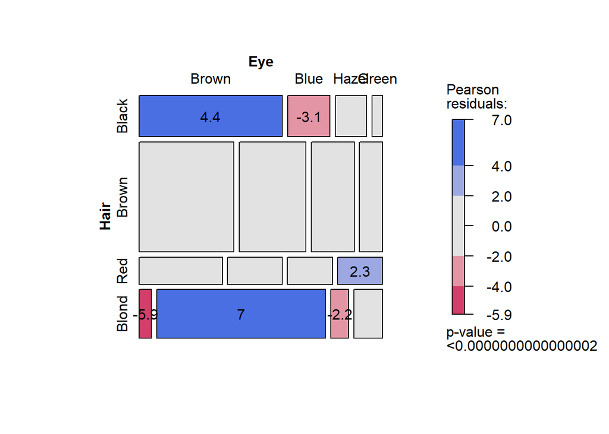

```r
mosaic(haireye, shade=T, labeling=labeling_residuals)
```

💡 學習重點：  
■ The Association between `Hair` and `Eye` is significant  
■ For Black-Hair:  
■ the propotion of Brown-Eye is significantly higher than `the expected`  
■ the propotion of Blue-Eye is significantly lower  
■ For Red-Hair:  
■ he propotion of Green-Eye is significantly higher  
■ For Blond-Hair:  
■ the propotion of Brown-Eye is significantly lower  
■ the propotion of Blue-Eye is significantly higher  
■ the propotion of Hazel-Eye is significantly lower

**D4. The `Expected Value` in Contingent Table**

```r
( expected = independence_table(haireye) )
```

```
       Eye
Hair      Brown    Blue  Hazel   Green
  Black  40.135  39.223 16.966 11.6757
  Brown 106.284 103.868 44.929 30.9189
  Red    26.385  25.785 11.154  7.6757
  Blond  47.196  46.123 19.951 13.7297
```

It is derived from the marginal probability in both directions

```r
(rowSums(haireye) %o% colSums(haireye)) / sum(haireye)
```

```
        Brown    Blue  Hazel   Green
Black  40.135  39.223 16.966 11.6757
Brown 106.284 103.868 44.929 30.9189
Red    26.385  25.785 11.154  7.6757
Blond  47.196  46.123 19.951 13.7297
```

**D5. Residuals**

```r
( residuals = haireye - expected )
```

```
       Eye
Hair        Brown      Blue     Hazel     Green
  Black  27.86486 -19.22297  -1.96622  -6.67568
  Brown  12.71622 -19.86824   9.07095  -1.91892
  Red    -0.38514  -8.78547   2.84628   6.32432
  Blond -40.19595  47.87669  -9.95101   2.27027
```

**D6. Standardized Residuals**

```r
( std.residuals = residuals / sqrt(expected)  )
```

```
       Eye
Hair        Brown      Blue     Hazel     Green
  Black  4.398399 -3.069377 -0.477352 -1.953684
  Brown  1.233458 -1.949477  1.353284 -0.345100
  Red   -0.074978 -1.730125  0.852253  2.282737
  Blond -5.850997  7.049590 -2.227844  0.612698
```

🧙 熱圖與馬賽克圖的比較 Heatmap.Rmd

### 【E】類別與連續變數之間的關係 - GGally

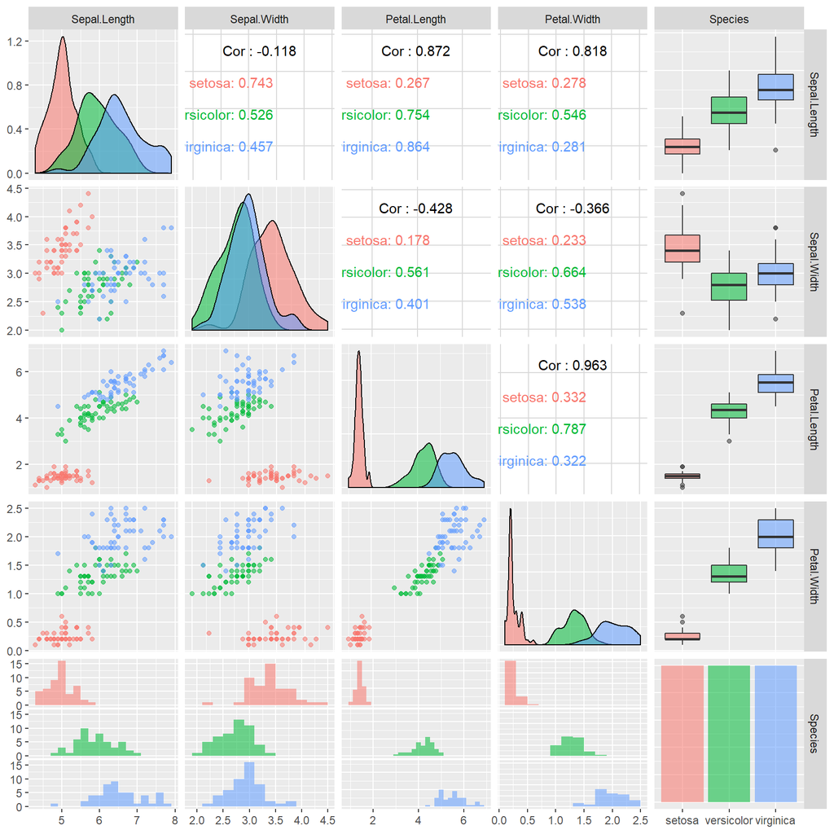

```r
library(GGally)
ggpairs(iris, aes(colour = Species, alpha=0.4),
        lower=list(combo = wrap("facethist", binwidth = 0.2)))
```

### 【F】類別與連續變數的各種可能關係圖示

##### F1. 單一類別變數

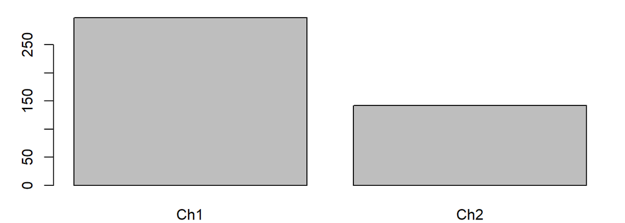

```r
par(cex=0.8, mar=c(2,3,1,1), mfrow=c(1,1))
table(W$Channel) %>% barplot
```

##### F2. 單一連續變數

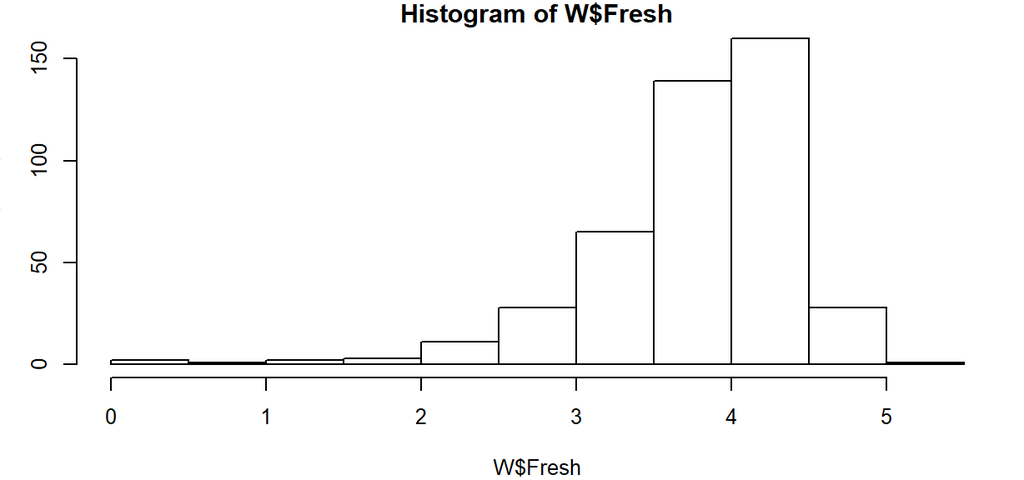

```r
par(cex=0.8, mar=c(4,3,1,1))
hist(W$Fresh)
```

##### F3. 兩類別變數

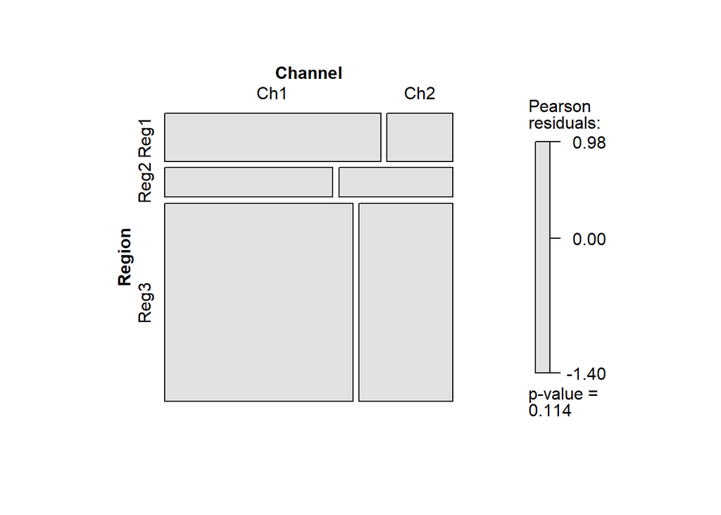

```r
structable(Channel ~ Region, W) %>%
  mosaic(shade=T, labeling=labeling_residuals)
```

💡 ： 如果類別變數裡面有太多分類(或各分類的數量很不平衡)，我們應該考慮使用熱圖

##### F4. 類別 X 數量

類別和數量變數擺在一起，就可以做分類統計

```r
tapply(W$Milk, W$Region, sum)
```

```
   Reg1    Reg2    Reg3
 270.08  163.29 1118.47
```

**分類平均**

```r
tapply(W$Milk, list(W$Channel, W$Region), mean)
```

```
      Reg1   Reg2   Reg3
Ch1 3.3686 3.2274 3.3470
Ch2 3.9628 3.8382 3.9263
```

**分類總和**

```r
tapply(W$Milk, list(W$Channel, W$Region), sum)
```

```
       Reg1   Reg2   Reg3
Ch1 198.750 90.366 706.21
Ch2  71.331 72.926 412.26
```

另一種做法

```r
xtabs(Milk ~ Channel + Region, data=W)
```

```
       Region
Channel    Reg1    Reg2    Reg3
    Ch1 198.750  90.366 706.214
    Ch2  71.331  72.926 412.260
```

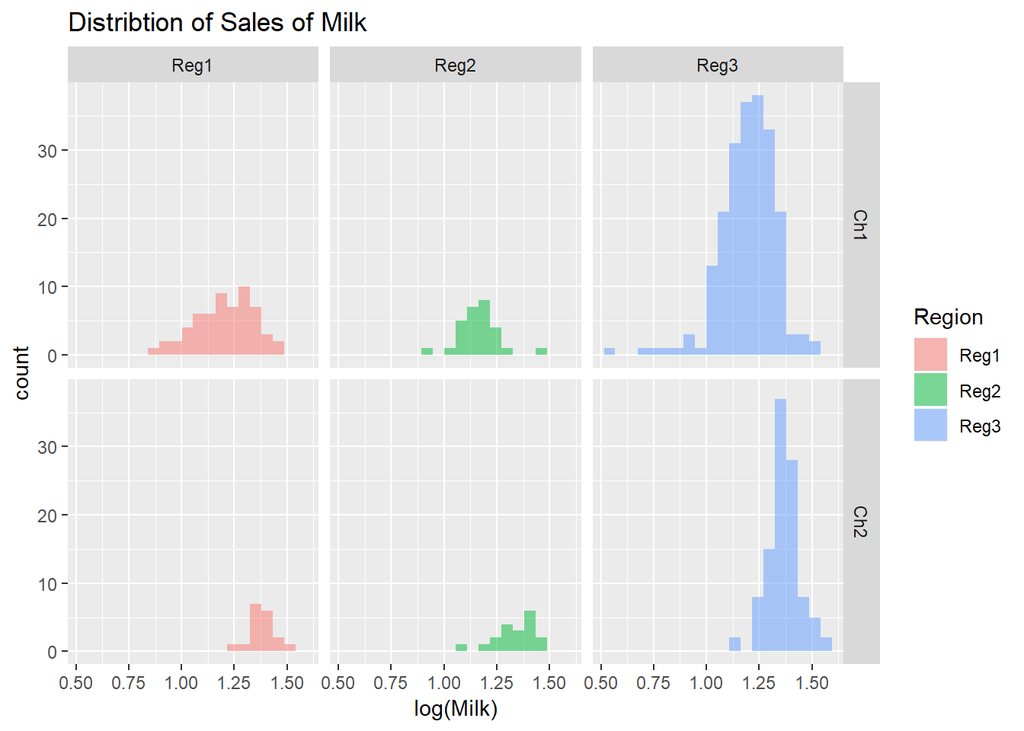

```r
ggplot(W, aes(x=log(Milk))) +
  geom_histogram(aes(fill=Region), alpha=0.5, bins=20) +
  facet_grid(Channel~Region) +
  labs(title="Distribtion of Sales of Milk")
```

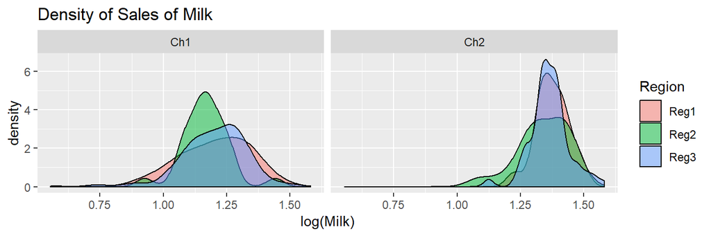

```r
ggplot(W, aes(x=log(Milk))) +
  geom_density(aes(fill=Region), alpha=0.5) +  # compare the density of Region
  facet_grid(~Channel) +                       # by Channel
  labs(title="Density of Sales of Milk")
```

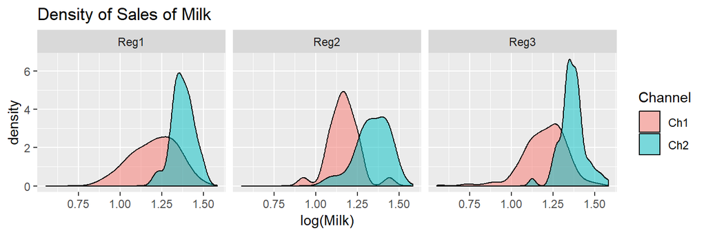

```r
ggplot(W, aes(x=log(Milk))) +
  geom_density(aes(fill=Channel), alpha=0.5) +  # compare the density of Channel
  facet_grid(~Region) +                         # by Region
  labs(title="Density of Sales of Milk")
```

##### F5. 數量 X 數量 (X 類別)

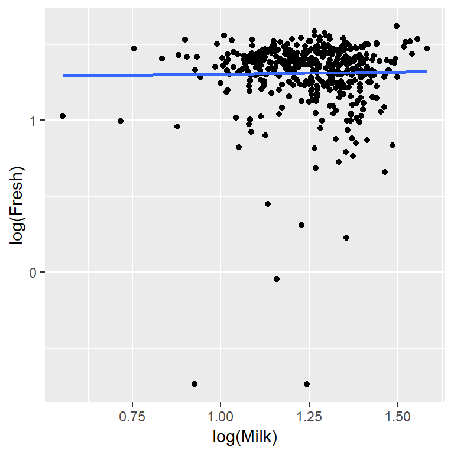

```r
ggplot(W, aes(x=log(Milk), y=log(Fresh))) +
  geom_point() +
  stat_smooth(method="lm",se=F)
```

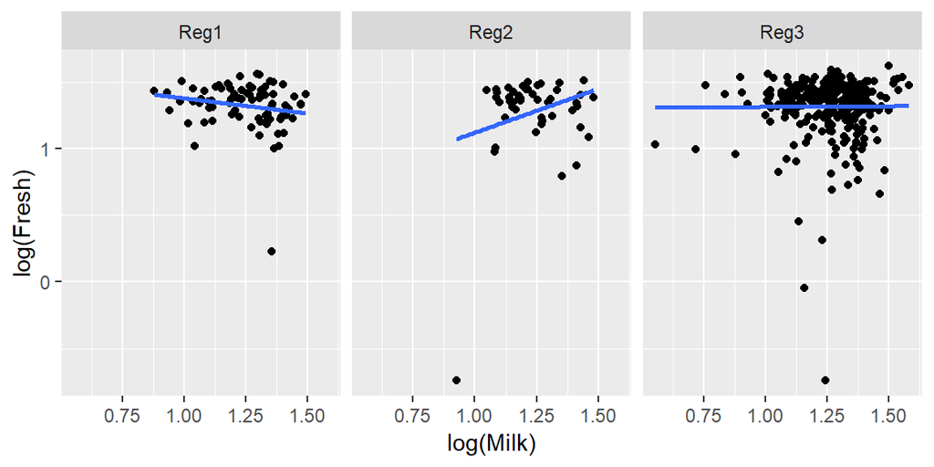

```r
ggplot(W, aes(x=log(Milk), y=log(Fresh))) +
  geom_point() +
  stat_smooth(method="lm", se=F) +
  facet_grid(~Region)
```

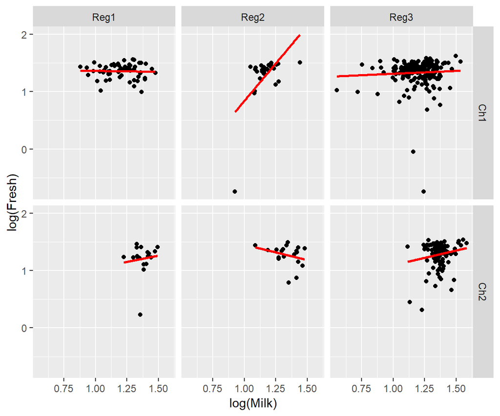

```r
ggplot(W, aes(x=log(Milk), y=log(Fresh))) +
  geom_point() +
  stat_smooth(method="lm", se=F, col='red') +
  facet_grid(Channel~Region)
```

💡 學習重點： 存在整個族群的關係和個別分群之中的關係有可能是不同(甚至是相反)的！

```r
load("../olist/data/olist.rdata")

P2 = group_by(R, order_id) %>%
  summarise(score = mean(review_score)) %>%
  right_join(O) %>% select(order_id, score) %>%
  right_join(I) %>% group_by(product_id) %>%
  summarise(score = mean(score)) %>%
  right_join(P) %>% left_join(TPC) %>%
  rename(category = product_category_name_english)
cor.test(P2$score, P2$product_photos_qty, use="complete.obs")
```

```
    Pearson's product-moment correlation

data:  P2$score and P2$product_photos_qty
t = 3.92, df = 32300, p-value = 0.00009
alternative hypothesis: true correlation is not equal to 0
95 percent confidence interval:
 0.010881 0.032669
sample estimates:
     cor
0.021778
```

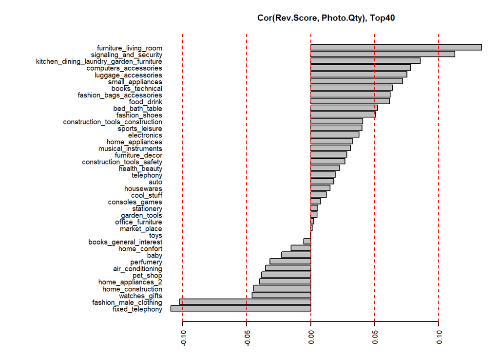

```r
K = 40
topK = table(P2$category) %>% sort %>% tail(K) %>% names
PK = filter(P2, category %in% topK)
par(cex=0.6, mar=c(4,20,4,2))
split(PK, PK$category) %>%
  sapply(function(df) {
    cor(df$score, df$product_photos_qty, use="complete.obs")
  }) %>% sort %>%
  barplot(horiz=T, las=2, main=sprintf(
    "Cor(Rev.Score, Photo.Qty), Top%d", K))
abline(v=seq(-0.1, 0.1, 0.05), col="red", lty=2)
```